# Homework 1 Assignment

Christopher Buckingham

##### In attempting to complete this assignment, I created a new project in RStudio, created a new Rmd file, and added some descriptive information to the top of the document. With an *.Rmd file ready I start making some charts. I am going to take the easy way out and work with the donation/disease dataset because it saves the effort of having to go out and find an interesting dataset (though there is no shortage of these)

##### I know that in order to produce something on the order of what we tinkered with in the first couple of classes, i’ll need the ggplot package installed and ready to go:

```r
require ("ggplot2")
```

##### Alright, that seemed to work. Now its time to dance with some data. The donation/disease dataset is conveniently already available in the hw1 branch and in *.csv form. I’ll need to read the file:

```r
donationdisease <-read.csv("Donation-disease.csv")
```

#### fail…. well, that definitely didn’t work as I expected.

##### I get an error indicating that the file cannot be found. I need to point R in the right direction so we can chart this data already. I add a bit of location information in front of the filename and R successfully reads the file. WINNING:

```r
donationdisease <-read.csv("../../Lab1/donation-disease.csv")
```

##### No errors this time. Awesome. Now, lets see what this data looks like:

```r
print(donationdisease)
```

```
##                                    Name                     Description
## 1                         Heart Disease             Jump Rope for Heart
## 2                               Suicide  Out of Darkness Overnight Walk
## 3                         Breast Cancer         Komen Race for the Cure
## 4                              Diabetes Step Out: Walk to Stop Diabetes
## 5                              HIV/AIDS                Ride to End Aids
## 6                       Prostate Cancer                        Movember
## 7  Motor Neuron Disease (including ALS)        ALS Ice Bucket Challenge
## 8 Chronic Obstructive Pulmonary Disease             Fight for Air Climb
##   MoneyRaised  Death
## 1        54.1 596577
## 2         3.2  39518
## 3       257.9  41374
## 4         4.2  73831
## 5        14.0   7683
## 6       147.0  21176
## 7        22.9   6849
## 8         7.0 142942
```

##### looks like everything is working so far. brilliant…. Let get a basic chart going using qplot:

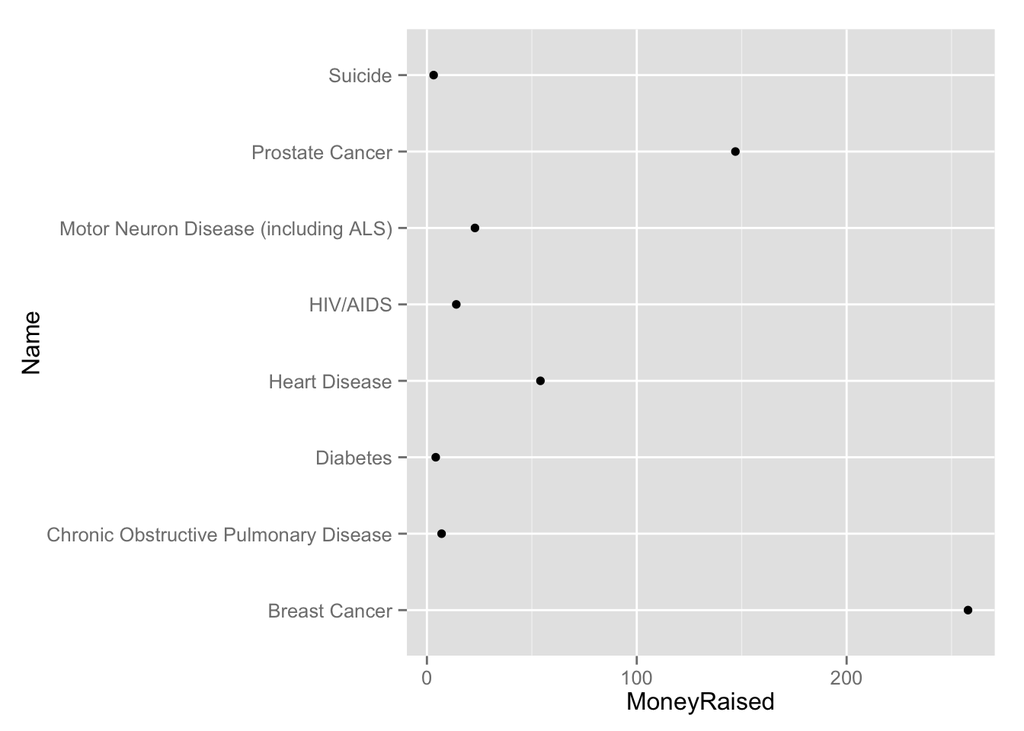

```r
qplot(MoneyRaised, Name, data=donationdisease)
```

##### On the first attempt, I was presented with an error: “object ‘Moneyraised’ not found.” It turns out that ‘Moneyraised’ should have a capitalized “R,” so I make the change and continue working. My qplot line is now working. Two of the first three words of the Team America World Police theme song run through my mind. I see dots. Amazing. This is the goal. Dots. I remember talking about this in class. Breasts are important.. but hearts? Not so much. You can lie about the data but data never lies. It is what it is. Lets jazz this thing up a bit:

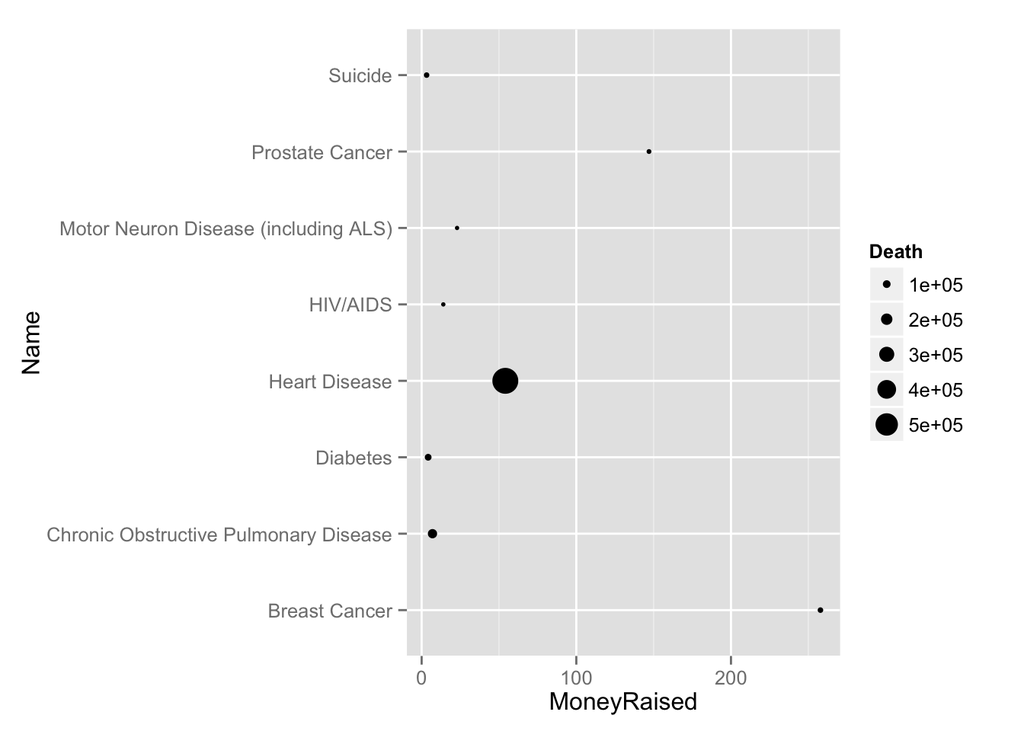

```r
qplot(MoneyRaised, Name, data=donationdisease, size=Death)
```

##### That looks better. More informative. I revisit the breasts vs. hearts thought. The death scale looks like death. Terrible. Need to google how to fix this:

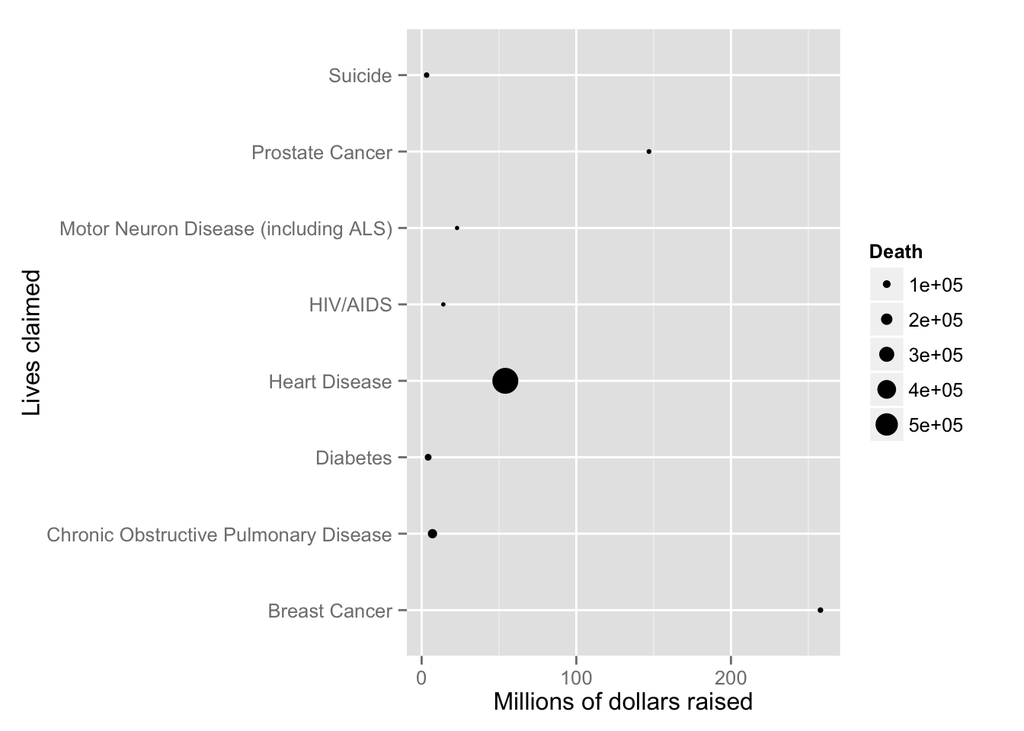

```r
qplot(MoneyRaised, Name, data=donationdisease, size=Death,xlab="Millions of dollars raised",ylab="Lives claimed")
```

##### Good news first: In my noodling I figured out how to replace the default labeling. Sweet. Baby steps. But – I still have no idea how to fix the death scale and scientific notation reminds me of chemistry. Exasperated sigh..

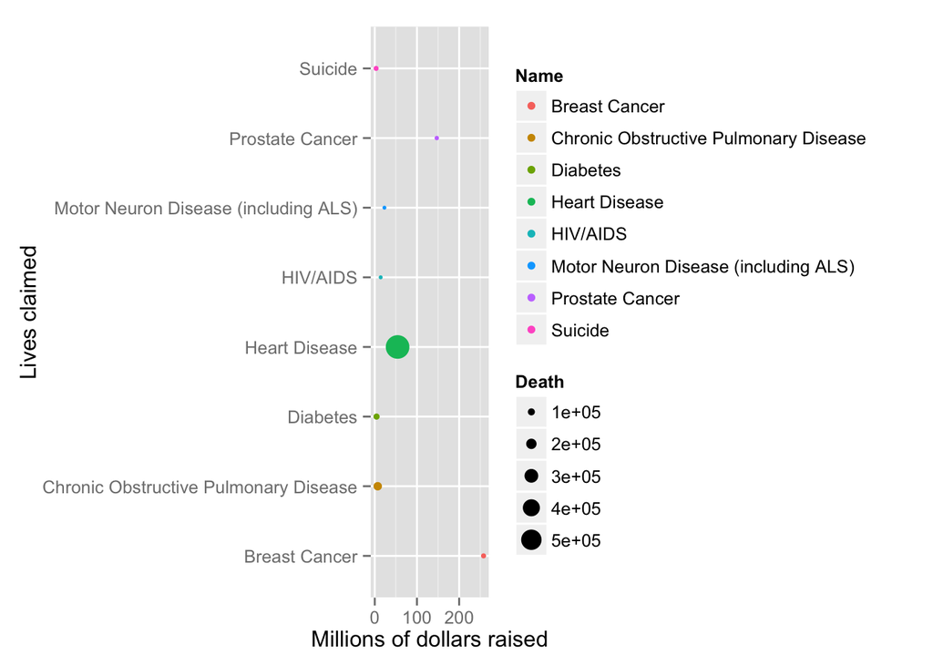

```r
qplot(MoneyRaised, Name, data=donationdisease, size=Death,xlab="Millions of dollars raised",ylab="Lives claimed", color=Name)
```

### Alright

##### Successfully creating a chart was nice, but I can’t figure out how to make it look good. I want to try to utilize G G P L O T in all of its glory:

```r
ggplot(donationdisease, aes(x=Death, y=MoneyRaised))
```

### FAIL

##### Seems GGPLOT requires a bit more handling:

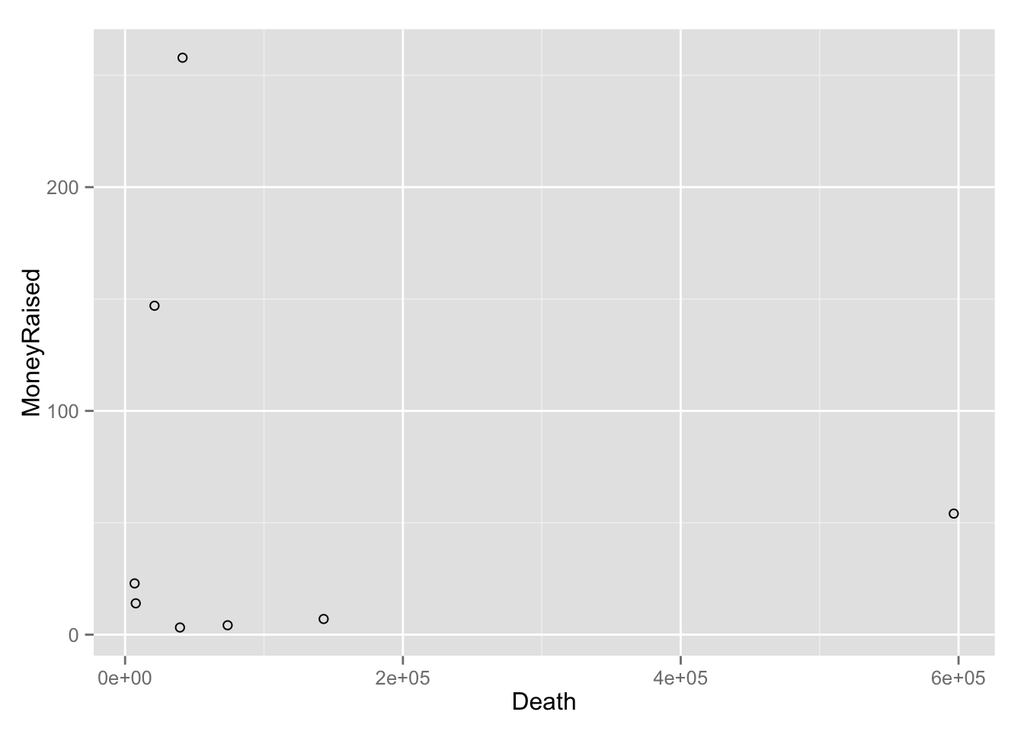

```r
ggplot(donationdisease, aes(x=Death, y=MoneyRaised)) +
geom_point(shape=1)
```

##### Still looks terrible… Let’s rescale deaths:

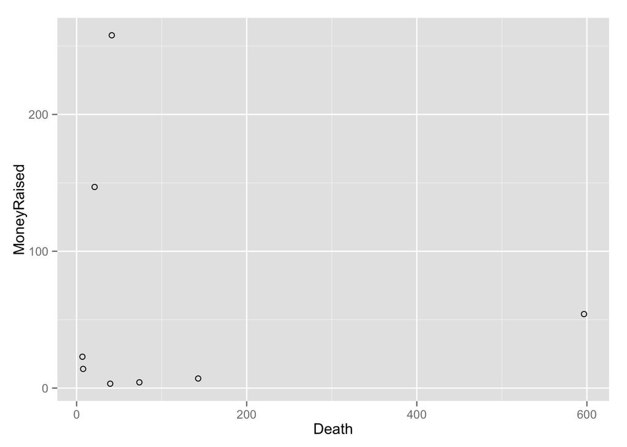

```r
donationdisease$Death<-donationdisease$Death/1000

ggplot(donationdisease, aes(x=Death, y=MoneyRaised)) +
geom_point(shape=1)
```

##### I can live with that, lets tinker around a bit more:

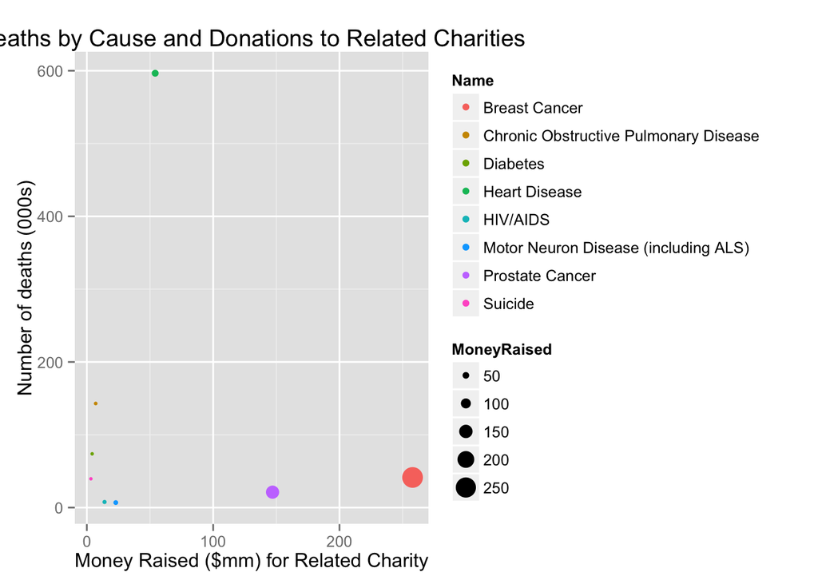

```r
ggplot(donationdisease, aes(y=Death, x=MoneyRaised, color=Name, size=MoneyRaised)) + geom_point()+ labs(title = "Deaths by Cause and Donations to Related Charities",x = "Money Raised ($mm) for Related Charity",y = "Number of deaths (000s)")
```

##### Okay, that is some progress. It’s not sexy but it displays the data in a meaningful way. Now that I know how to properly git submit this thing, we are moving forward.